# gabovicen_OriginalHomeworkCode_03

Gabriel Vicencio

10/4/2021

### AN/BI 588: Homework 03

```r
library(curl)
```

```r
library(ggplot2)
```

```r
f <- curl("https://raw.githubusercontent.com/fuzzyatelin/fuzzyatelin.github.io/master/AN588_Fall21/zombies.csv")
d <- read.csv(f, header = TRUE, sep = ",", stringsAsFactors = FALSE)
head(d)
```

```
##   id first_name last_name gender   height   weight zombies_killed
## 1  1      Sarah    Little Female 62.88951 132.0872              2
## 2  2       Mark    Duncan   Male 67.80277 146.3753              5
## 3  3    Brandon     Perez   Male 72.12908 152.9370              1
## 4  4      Roger   Coleman   Male 66.78484 129.7418              5
## 5  5      Tammy    Powell Female 64.71832 132.4265              4
## 6  6    Anthony     Green   Male 71.24326 152.5246              1
##   years_of_education                           major      age
## 1                  1                medicine/nursing 17.64275
## 2                  3 criminal justice administration 22.58951
## 3                  1                       education 21.91276
## 4                  6                  energy studies 18.19058
## 5                  3                       logistics 21.10399
## 6                  4                  energy studies 21.48355
```

This data includes the first name, last name, and gender of the entire population of 1000 people who have survived the zombie apocalypse and are now ekeing out an existence somewhere on the East Coast, along with several other variables (height, weight, age, number of years of education, number of zombies they have killed, and college major

1. Calculate the population mean and standard deviation for each quantitative random variable (height, weight, age, number of zombies killed, and years of education). NOTE: You will not want to use the built in var() and sd() commands as these are for samples.

```r
summary(d)
```

```
##        id          first_name         last_name            gender
##  Min.   :   1.0   Length:1000        Length:1000        Length:1000
##  1st Qu.: 250.8   Class :character   Class :character   Class :character
##  Median : 500.5   Mode  :character   Mode  :character   Mode  :character
##  Mean   : 500.5
##  3rd Qu.: 750.2
##  Max.   :1000.0
##      height          weight       zombies_killed   years_of_education
##  Min.   :54.15   Min.   : 90.29   Min.   : 0.000   Min.   :0.000
##  1st Qu.:64.68   1st Qu.:131.81   1st Qu.: 2.000   1st Qu.:2.000
##  Median :67.50   Median :142.89   Median : 3.000   Median :3.000
##  Mean   :67.63   Mean   :143.91   Mean   : 2.992   Mean   :2.996
##  3rd Qu.:70.38   3rd Qu.:156.28   3rd Qu.: 4.000   3rd Qu.:4.000
##  Max.   :80.53   Max.   :210.79   Max.   :11.000   Max.   :8.000
##     major                age
##  Length:1000        Min.   :10.66
##  Class :character   1st Qu.:18.07
##  Mode  :character   Median :19.90
##                     Mean   :20.05
##                     3rd Qu.:21.94
##                     Max.   :29.59
```

```r
names(d)
```

```
##  [1] "id"                 "first_name"         "last_name"
##  [4] "gender"             "height"             "weight"
##  [7] "zombies_killed"     "years_of_education" "major"
## [10] "age"
```

1. Calculate the population mean and standard deviation for each quantitative random variable (height, weight, age, number of zombies killed, and years of education). NOTE: You will not want to use the built in var() and sd() commands as these are for samples.

## a) Mean

```r
mean(d$height)
```

```
## [1] 67.6301
```

```r
mean(d$weight)
```

```
## [1] 143.9075
```

```r
mean(d$zombies_killed)
```

```
## [1] 2.992
```

```r
mean(d$years_of_educatio)
```

```
## [1] 2.996
```

```r
mean(d$age)
```

```
## [1] 20.04696
```

## b) standard deviation #cece comments - for standard deviation, the homework says you’re not able to use the built in sd function because it is meant for samples, not populations. To find my sds I used the summary function which gives summary stats for each variable. Not 100% sure thats what he intended for us to do but it seemed to work

```r
sd(d$height)*(sqrt((length(d$height)-1)/length(d$height)))
```

```
## [1] 4.30797
```

```r
sd(d$weight)
```

```
## [1] 18.40106
```

```r
sd(d$zombies_killed)
```

```
## [1] 1.748426
```

```r
sd(d$years_of_educatio)
```

```
## [1] 1.676543
```

```r
sd(d$age)
```

```
## [1] 2.965066
```

## 2) Use {ggplot} to make boxplots of each of these variables by gender.

#cece-looks good I did the same thing, but make sure you call ggplot before you run these. Also I would consider naming each ggplot a different letter so you don’t accidentially mix them up

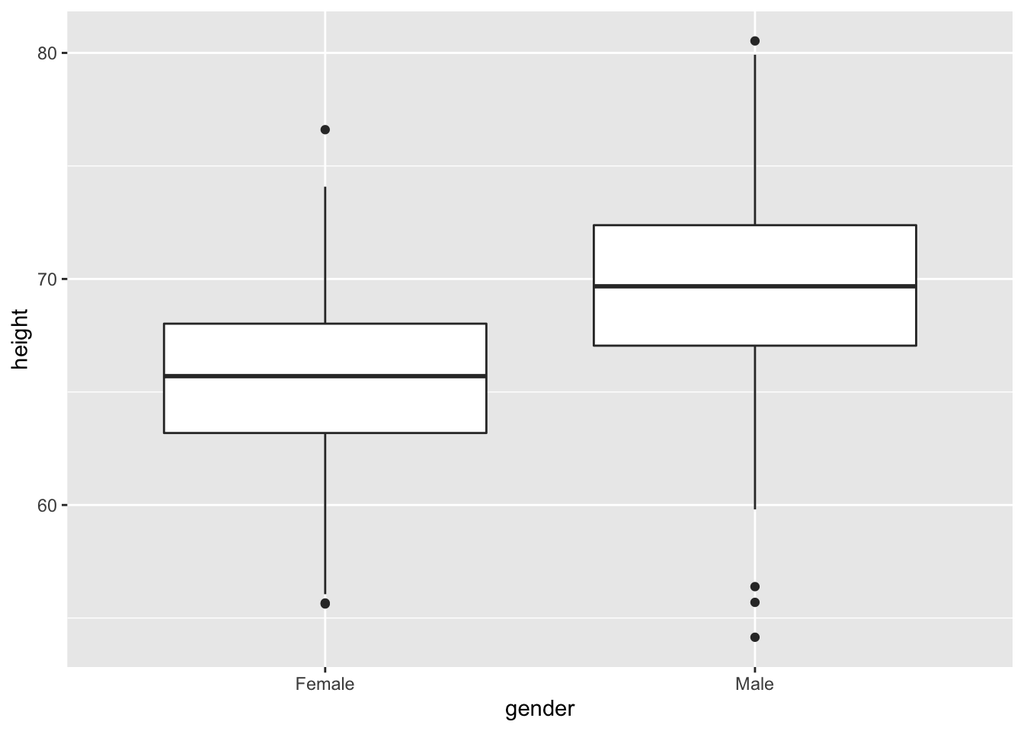

```r
g<- ggplot(d, aes(x = gender, y = height)) + geom_boxplot()
g
```

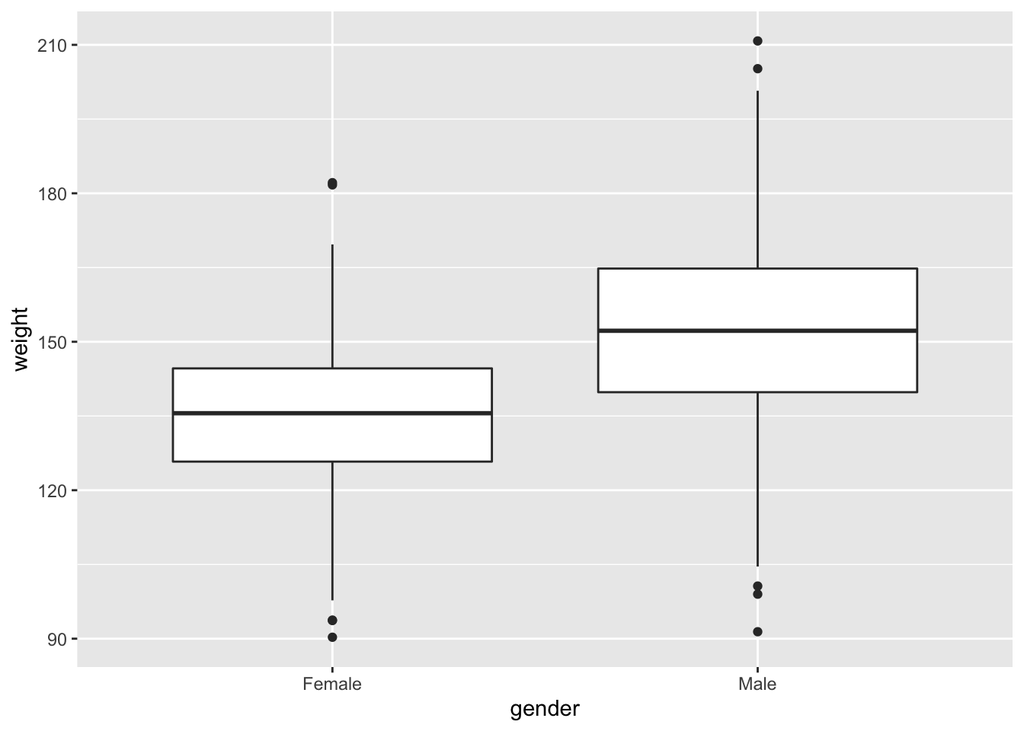

```r
g<- ggplot(d, aes(x = gender, y = weight)) + geom_boxplot()
g
```

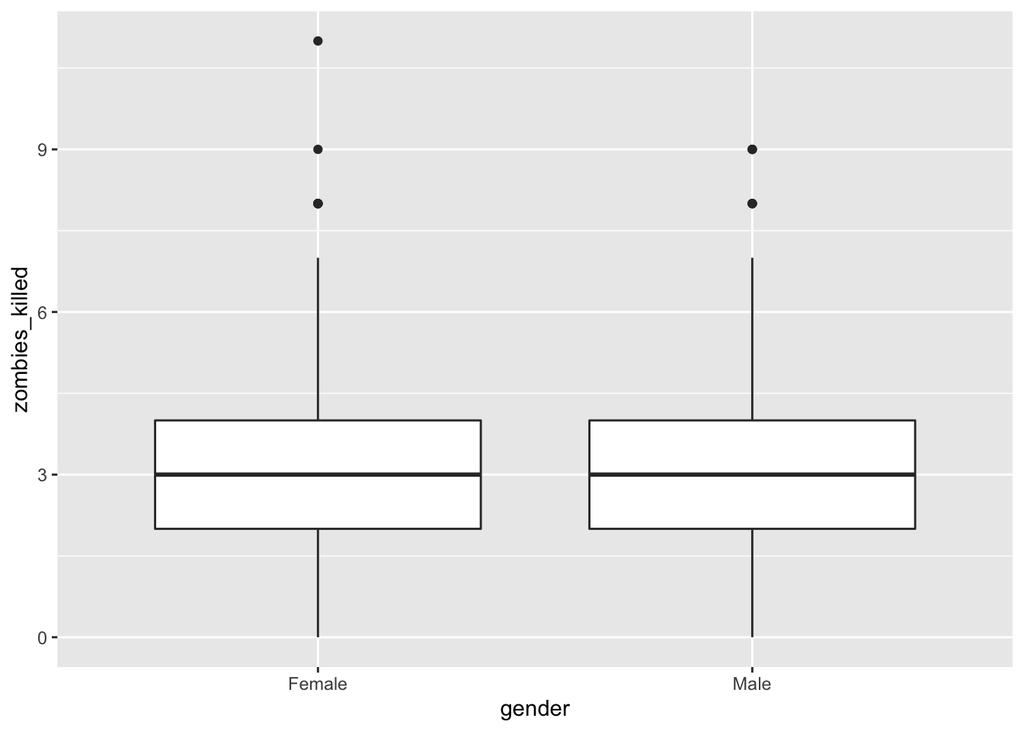

```r
g<- ggplot(d, aes(x = gender, y = zombies_killed)) + geom_boxplot()
g
```

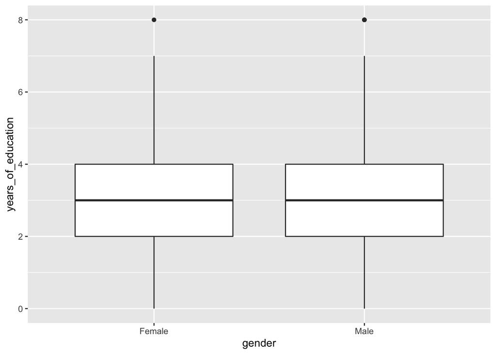

```r
g<- ggplot(d, aes(x = gender, y = years_of_education)) + geom_boxplot()
g
```

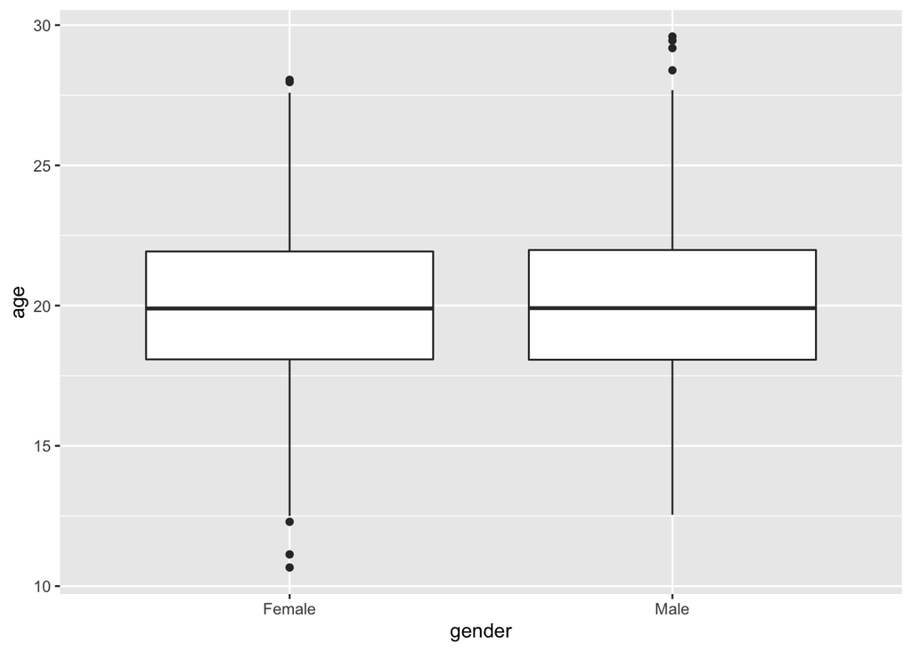

```r
g<- ggplot(d, aes(x = gender, y = age)) + geom_boxplot()
g
```

## 3) Use {ggplot} to make scatterplots of height and weight in relation to age. Do these variables seem to be related? In what way?

#cece-looks good, I’m realizing I didn’t add a line to my scatterplots, thanks for the reminder

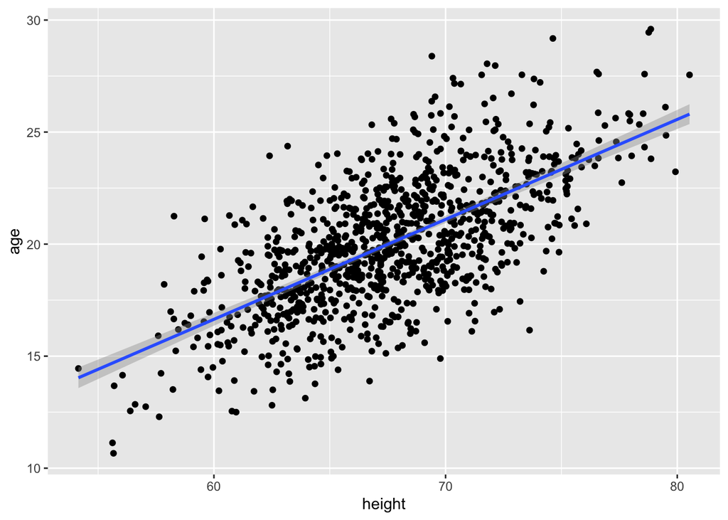

```r
library(ggplot2)
g<- ggplot(d, aes(x = height, y = age)) + geom_point() + geom_smooth(method = "lm", formula = y ~ x)
g
```

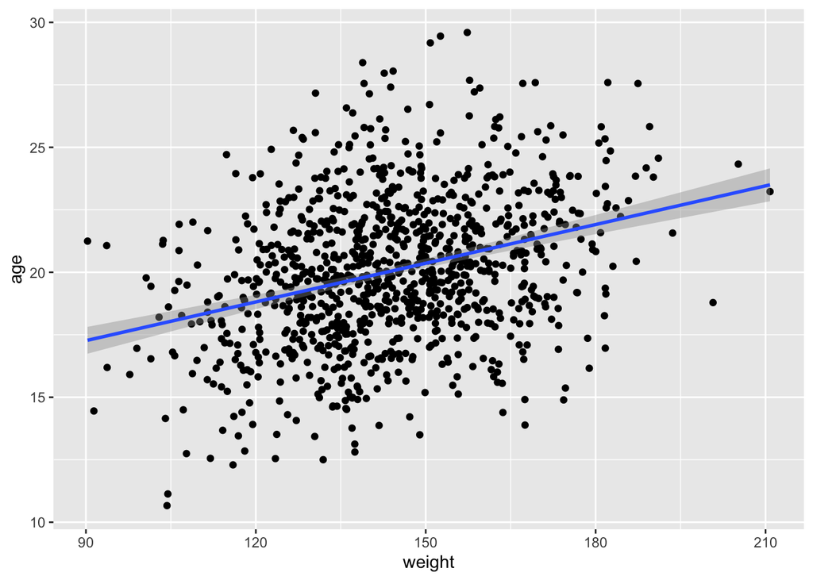

```r
g<- ggplot(d, aes(x = weight, y = age)) + geom_point() + geom_smooth(method = "lm", formula = y ~ x)
g
```

## 4) Using histograms and Q-Q plots, check whether the quantitative variables seem to be drawn from a normal distribution. Which seem to be and which do not (hint: not all are drawn from the normal distribution)? For those that are not normal, can you determine from which common distribution they are drawn?

#cece - looks good - I got the same results, I just ran qq plots first and only ran histograms on the ones I identified as non-normal.

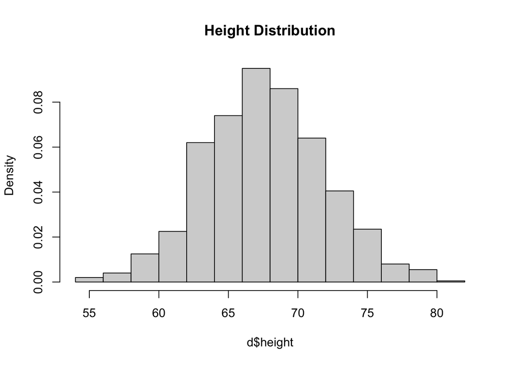

```r
hist(d$height, probability = TRUE, main = "Height Distribution")
```

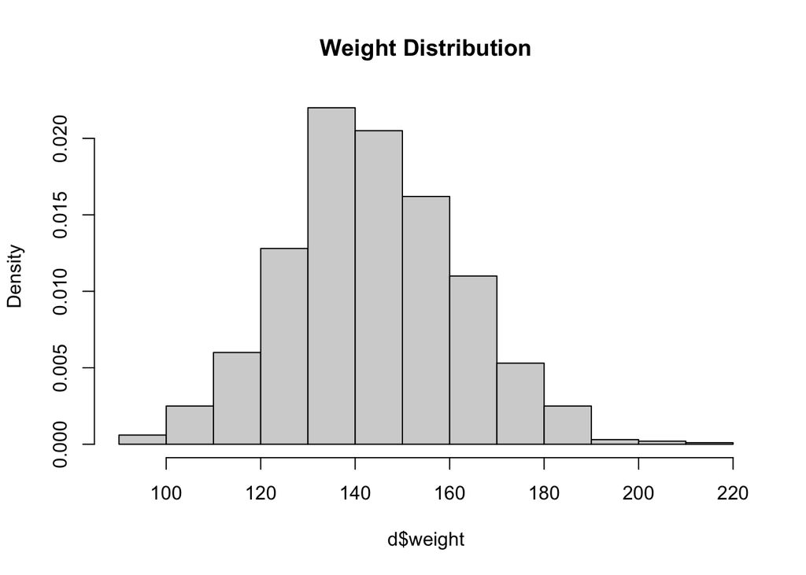

```r
hist(d$weight, probability = TRUE, main = "Weight Distribution")
```

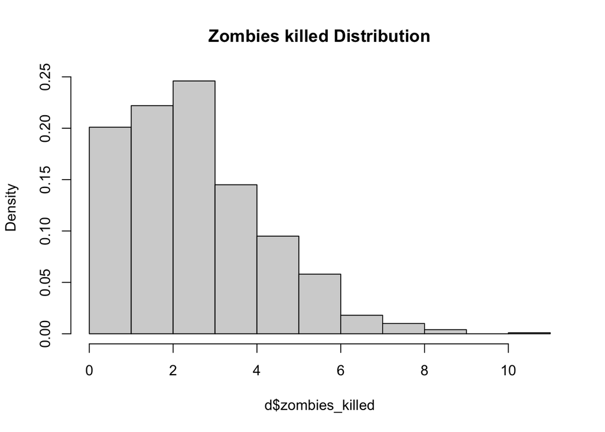

```r
hist(d$zombies_killed, probability = TRUE, main = "Zombies killed Distribution")
```

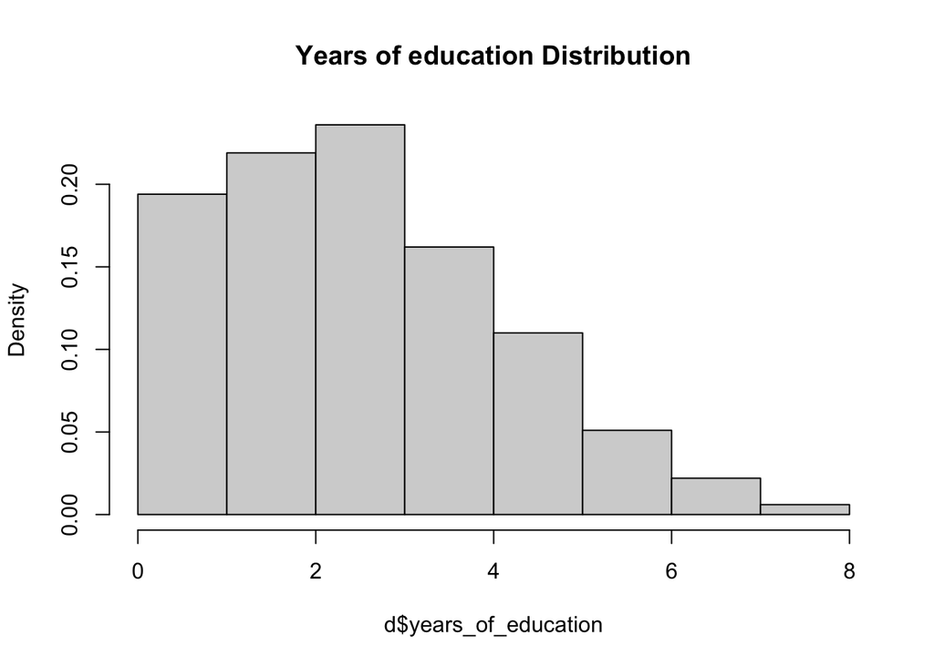

```r
hist(d$years_of_education, probability = TRUE, main = "Years of education Distribution")
```

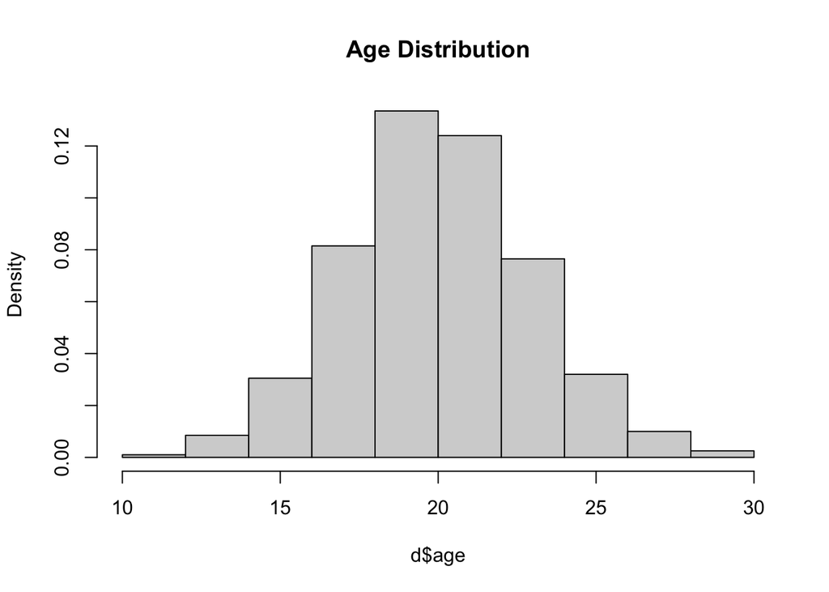

```r
hist(d$age, probability = TRUE, main = "Age Distribution")
```

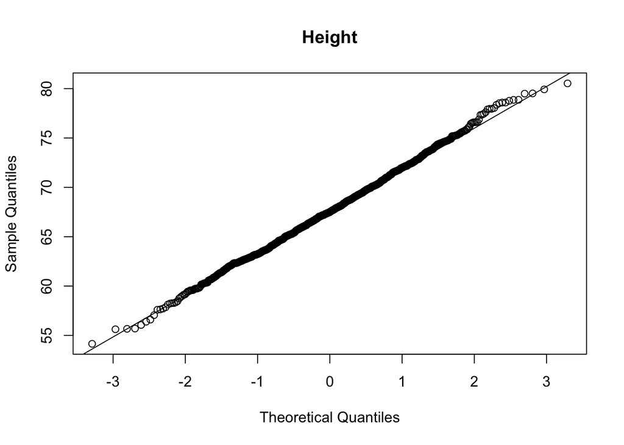

```r
qqnorm(d$height, main = "Height")
qqline(d$height)
```

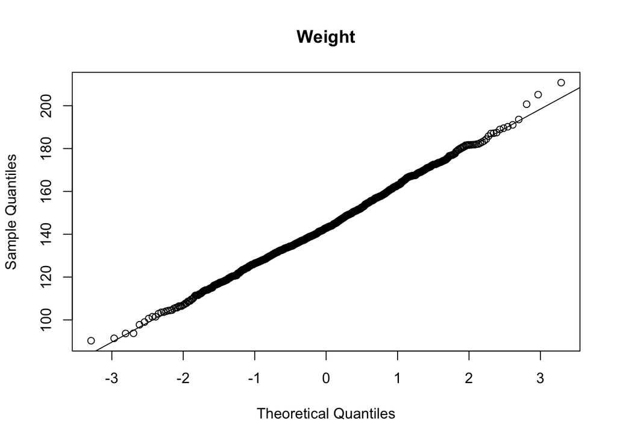

```r
qqnorm(d$weight, main = "Weight")
qqline(d$weight)
```

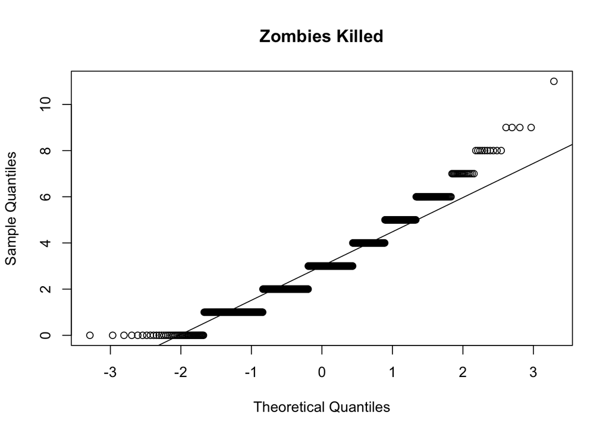

```r
qqnorm(d$zombies_killed, main = "Zombies Killed")
qqline(d$zombies_killed)
```

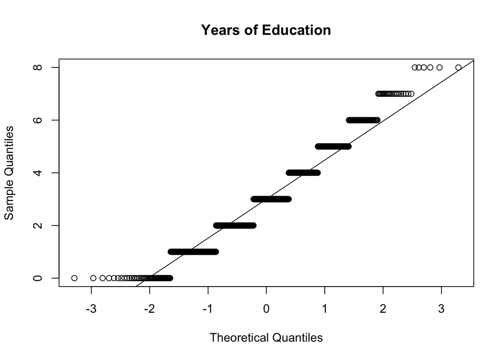

```r
qqnorm(d$years_of_education, main = "Years of Education")
qqline(d$years_of_education)
```

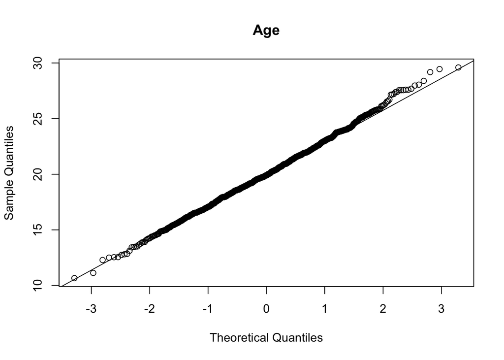

```r
qqnorm(d$age, main = "Age")
qqline(d$age)
```

## 5) Now use the sample() function to sample ONE subset of 30 zombie survivors (without replacement) from this population and calculate the mean and sample standard deviation for each variable. Also estimate the standard error for each variable, and construct the 95% confidence interval for each mean. Note that for the variables that are not drawn from the normal distribution, you may need to base your estimate of the CIs on slightly different code than for the normal…

#cece notes - I used a slightly different command, but it looks like we got the same results

```r
library(dplyr)
s<- sample_n(d, 30, replace = FALSE, prob = NULL)
s
```

```
##     id first_name last_name gender   height   weight zombies_killed
## 1  180      Nancy       Fox Female 69.26646 154.9889              4
## 2  391       Paul   Sanders   Male 71.89275 162.3514              5
## 3  656    Kathryn  Peterson Female 64.72491 126.4283              4
## 4  662     Martin     Banks   Male 73.73934 180.1173              1
## 5  670    Gregory    Walker   Male 69.40674 138.8645              3
## 6  450     Brenda    Greene Female 63.32991 134.3688              2
## 7  367     Sandra    Knight Female 68.64705 139.1861              2
## 8  789     George    Willis   Male 74.51423 166.9047              3
## 9  580    Mildred      Ross Female 69.17858 138.7701              4
## 10  85    Anthony    Burton   Male 69.09528 162.6679              3
## 11 315      Tammy    Martin Female 65.69532 123.4174              5
## 12 758       Lisa  Campbell Female 67.45969 146.1202              6
## 13 774    Stephen    Burton   Male 63.18440 135.8098              5
## 14 873       Rose      Hart Female 63.39950 134.4014              5
```

[output cut: 47 more lines]

# mean

#these are all good, just for question 6 you will have to name each mean and sd something so you can reference it when you’re making the confidence intervals

```r
mean(s$height)
```

```
## [1] 68.20672
```

```r
mean(s$weight)
```

```
## [1] 145.7955
```

```r
mean(s$zombies_killed)
```

```
## [1] 3.266667
```

```r
mean(s$years_of_educatio)
```

```
## [1] 3.3
```

```r
mean(s$age)
```

```
## [1] 20.48296
```

## b) standard deviation

```r
sd(d$height)*(sqrt((length(d$height)-1)/length(d$height)))
```

```
## [1] 4.30797
```

```r
sd(s$weight)
```

```
## [1] 19.48538
```

```r
sd(s$zombies_killed)
```

```
## [1] 1.740657
```

```r
sd(s$years_of_educatio)
```

```
## [1] 1.342925
```

```r
sd(s$age)
```

```
## [1] 3.242018
```

## 6) Now draw 99 more random samples of 30 zombie apocalypse survivors, and calculate the mean for each variable for each of these samples. Together with the first sample you drew, you now have a set of 100 means for each variable (each based on 30 observations), which constitutes a sampling distribution for each variable. What are the means and standard deviations of this distribution of means for each variable? How do the standard deviations of means compare to the standard errors estimated in [5]? What do these sampling distributions look like (a graph might help here)? Are they normally distributed? What about for those variables that you concluded were not originally drawn from a normal distribution?